# Continuous random variables

POLI 210 - Seminar 5

Brad LeVeck

2026-09-30

## Today’s questions

- How does an area describe the probability of an interval?
- How do we calculate and simulate normal probabilities?
- How can a continuous model approximate discrete vote counts?
- How does a distribution of possible partners become a payoff distribution?

We will read integrals as accumulated areas and use geometry or R to calculate them.

**Reading:** PSD Chapter 4, Sections 4.1-4.4.2.

## Probability mass and probability density

Last week, a PMF assigned probability to each possible value:

$$p_X(x)=P(X=x),\qquad \sum_x p_X(x)=1.$$

For today’s continuous models, a **density** allocates probability over intervals:

$$P(a<X\le b)=\text{area under }f_X\text{ between }a\text{ and }b.$$

The random variable still maps outcomes to numbers. We change how we describe its distribution.

## A uniform waiting-time model

Suppose an outreach worker arrives after $T\sim\operatorname{Unif}(0,10)$ minutes. All intervals of the same length inside $[0,10]$ have equal probability.

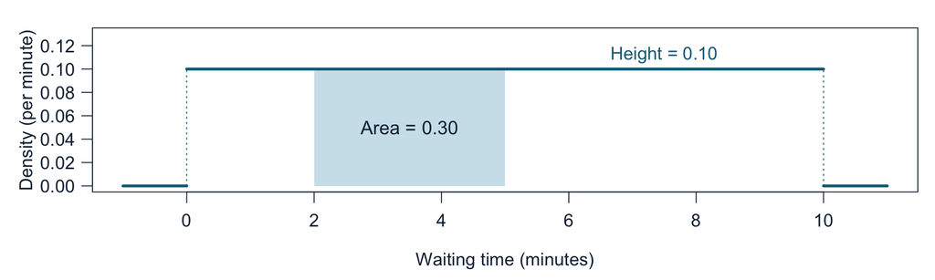

$$P(2\le T\le5)=(5-2)(0.1)=0.3.$$

## Why point probabilities are not enough

Suppose each exact time in our uniform $[0,10]$ model had probability $c>0$.

For $N$ distinct times,

$$P(T\in\{t_1,\ldots,t_N\})=Nc.$$

We can choose more than $1/c$ distinct times. That would give a probability greater than one.

Each exact time has probability zero. The whole interval has probability one:

$$P(T=t)=0,\qquad P(0\le T\le10)=1.$$

The point probabilities alone lose the distribution’s information. The density preserves how probability spreads across intervals.

## Reading an integral

$$P(a<X\le b)=\int_a^b f_X(x)\,dx.$$

The bounds identify the interval. The density supplies the height.

Imagine dividing the interval into thin rectangles:

$$\text{probability}\ \approx\ \sum_i f_X(x_i)\,\Delta x.$$

The integral is the limit as those rectangles become arbitrarily thin.

For the uniform example, the rectangles all have height $0.1$.

## A sloping density

A different model has $f_T(t)=t/50$ on $[0,10]$, zero elsewhere.

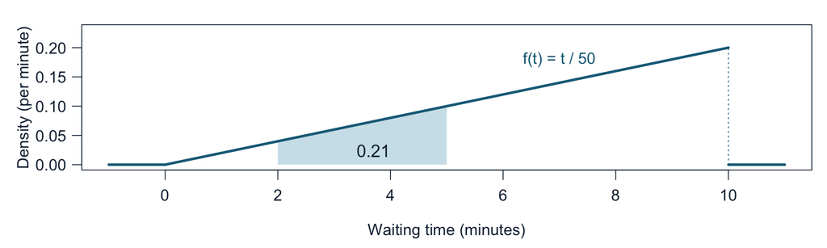

The shaded trapezoid has area $(5-2)(0.04+0.10)/2=0.21$. No antiderivative is needed.

## What makes a valid density?

$$f_X(x)\ge0,\qquad \int_{-\infty}^{\infty}f_X(x)\,dx=1.$$

A uniform wait between 0 and 10 **minutes** has density $0.1$ per minute.

Measure that same wait in **hours**. Its range is $[0,1/6]$ and its density is $6$ per hour.

$$P(T\le3\text{ minutes})=3(0.1)=0.05(6)=0.3.$$

Density can exceed one. Area is a probability and stays between zero and one.

## The CDF still answers the same question

$$F_X(x)=P(X\le x).$$

For a density model,

$$F_X(x)=\int_{-\infty}^{x} f_X(t)\,dt,\qquad
P(a<X\le b)=F_X(b)-F_X(a).$$

The CDF accumulates area from the left. Where it is differentiable, its slope is the density: $F_X'(x)=f_X(x)$.

For continuous density models, including or excluding the endpoints does not change an interval’s probability.

## A uniform CDF

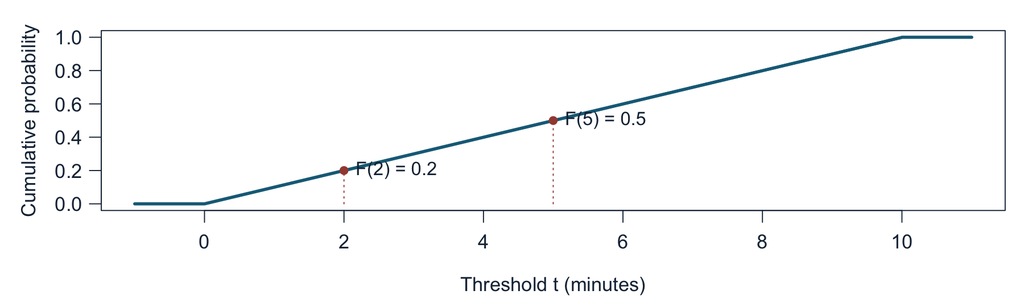

Here $F_T(t)=t/10$ within $[0,10]$, with 0 to the left and 1 to the right.

$$P(2<T\le5)=F_T(5)-F_T(2)=0.5-0.2=0.3.$$

## Narrow intervals and a single point

For $T\sim\operatorname{Unif}(0,10)$ minutes, zoom in around 5 minutes:

| Interval | Width (minutes) | Probability | Probability / width |
| --- | --- | --- | --- |
| $[4.5,5.5]$ | 1 | 0.1 | 0.1 per minute |
| $[4.9,5.1]$ | 0.2 | 0.02 | 0.1 per minute |
| $[4.99,5.01]$ | 0.02 | 0.002 | 0.1 per minute |

The interval’s **probability** shrinks toward zero. Its probability **per unit of width** stays at $0.1$ per minute.

For a smooth density and a narrow interval,

$$P(x-\epsilon\le X\le x+\epsilon)\approx 2\epsilon f_X(x).$$

Width times density gives probability, just as time times speed gives distance.

## Density at a point is a local rate

Where the density is continuous at $x$,

$$f_X(x)=\lim_{\epsilon\downarrow0}
\frac{P(x-\epsilon\le X\le x+\epsilon)}{2\epsilon}.$$

Divide probability by interval width, then shrink the interval. The limit gives a rate at $x$, with no particular interval left to specify.

Some authors write $p(x)$ for this density. Here we use $f_X(x)$. That notation does not turn density into $P(X=x)$.

| R expression | Result | Meaning |
| --- | --- | --- |
| `dunif(5, 0, 10)` | 0.1 | Density at 5, per minute |
| `punif(5, 0, 10)` | 0.5 | Probability $P(T\le5)$ |

`punif()` includes an implicit interval: everything at or below its argument.

## Four useful R prefixes

| Question | Uniform example | Normal example |
| --- | --- | --- |
| Density height at $x$ | `dunif(x, 0, 10)` | `dnorm(x, mu, sigma)` |
| Probability at or below $x$ | `punif(x, 0, 10)` | `pnorm(x, mu, sigma)` |
| Value at cumulative probability $p$ | `qunif(p, 0, 10)` | `qnorm(p, mu, sigma)` |
| Simulated values | `runif(N, 0, 10)` | `rnorm(N, mu, sigma)` |

For a discrete distribution, `d` gives **mass**. For a continuous distribution, `d` gives **density**.

## Simulation checks an area calculation

```r
set.seed(93001)
waits <- runif(50000, min = 0, max = 10)
mean(waits >= 2 & waits <= 5)
```

```
[1] 0.30034
```

```r
punif(5, 0, 10) - punif(2, 0, 10)
```

```
[1] 0.3
```

One draw is one waiting time. The logical comparison identifies draws inside the interval.

**Demo 1:** Change the number of repetitions. The underlying probability stays at $0.3$. Demo 2 optionally checks the sloping-density example.

## Expectation as a weighted average

$$E[X]=\int_{-\infty}^{\infty}x f_X(x)\,dx.$$

This is the continuous counterpart of $\sum_x x p_X(x)$.

Small intervals have approximate weight $f_X(x)\Delta x$. Multiply each representative value by its weight, then add.

For $T\sim\operatorname{Unif}(0,10)$, symmetry gives $E[T]=5$ minutes.

**Question:** Does every density have its mean at the middle of its support?

## Variance measures variation in outcomes

$$\operatorname{Var}(X)=E[(X-\mu)^2]=E[X^2]-\mu^2.$$

The formulas and interpretation carry over from discrete random variables.

For $T\sim\operatorname{Unif}(0,10)$,

$$E[T]=5,\qquad \operatorname{Var}(T)=\frac{100}{12}\approx8.33,
\qquad \operatorname{SD}(T)\approx2.89.$$

Variance uses minutes squared. SD uses minutes.

More simulated waits improve our estimate of this variance. They do not make the model’s waiting times less variable.

## Transformations and expectation

The rules for fixed constants still hold:

$$E[aX+b]=aE[X]+b,\qquad
\operatorname{Var}(aX+b)=a^2\operatorname{Var}(X).$$

For a general transformation $g$, average its values over the distribution:

$$E[g(X)]=\int g(x)f_X(x)\,dx.$$

For example, $E[T^2]=100/3$, whereas $(E[T])^2=25$.

The two calculations answer different questions.

## A finite population of potential partners

Four people have minimum acceptable payments of **5, 15, 15, and 45** points. Choose one person uniformly at random.

| Minimum payment $c$ | 5 | 15 | 45 |
| --- | --- | --- | --- |
| $P(C=c)$ | $1/4$ | $1/2$ | $1/4$ |
| $F_C(c)$ | $1/4$ | $3/4$ | $1$ |

The average minimum payment is $E[C]=20$.

Each person has equal probability. The three distinct payment values do not.

## Expected payoff and the mean partner

An 80-point project succeeds when your offer $a$ meets the partner’s minimum.

$$Y_a=\begin{cases}80-a,&C\le a,\\0,&C>a.\end{cases}$$

At an offer of 15, the four possible earnings are $65,65,65,0$.

$$E[Y_{15}]=48.75.$$

A hypothetical partner with the **mean** minimum of 20 rejects that offer, giving a payoff of zero.

The threshold transformation cannot generally be applied after averaging.

## Crossing payoff CDFs

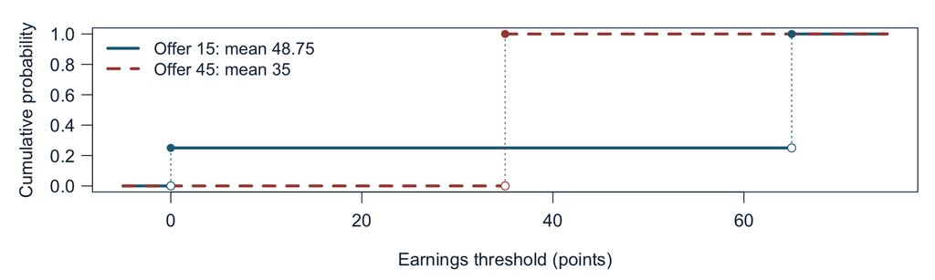

Offer 15 has the higher mean. Offer 45 is more likely to exceed 20 points. Only offer 15 can exceed 50 points.

**Demo 8:** Read the tail probability as $P(Y>y)=1-F_Y(y)$.

## Break

We have connected density, cumulative probability, and moments.

After the break: the normal model, election forecasts, and a discrete vote-count approximation.

## The normal model

$$X\sim\operatorname{Norm}(\mu,\sigma),\qquad
E[X]=\mu,\quad \operatorname{Var}(X)=\sigma^2.$$

Following PSD, the second parameter is the **standard deviation**.

$$f_X(x)=\frac{1}{\sigma\sqrt{2\pi}}
\exp\left[-\frac12\left(\frac{x-\mu}{\sigma}\right)^2\right].$$

This formula defines the curve. We use `dnorm()` to draw it and `pnorm()` to calculate its accumulated area.

No hand evaluation of a normal integral is required.

## Location and spread

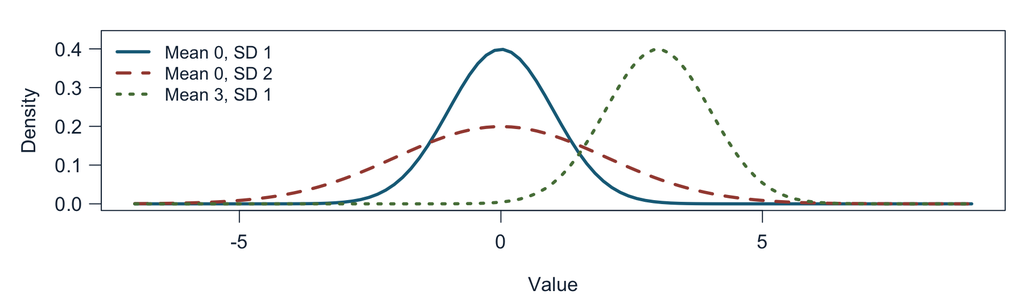

Changing $\mu$ shifts the center. Increasing $\sigma$ spreads the same total area over a wider range and lowers the peak.

## Standardization

If $X\sim\operatorname{Norm}(\mu,\sigma)$, then

$$Z=\frac{X-\mu}{\sigma}\sim\operatorname{Norm}(0,1).$$

$Z$ measures distance from the mean in standard deviations.

$$P(X\le x)=P\left(Z\le\frac{x-\mu}{\sigma}\right).$$

We can use `pnorm(x, mean = mu, sd = sigma)` directly, or standardize first and use `pnorm((x - mu) / sigma)`.

## The normal model’s central areas

| Distance from the mean | Probability |
| --- | --- |
| Within one SD | About 68% |
| Within two SDs | About 95% |
| Within three SDs | About 99.7% |

For example,

$$P(\mu-\sigma\le X\le\mu+\sigma)
=P(-1\le Z\le1)\approx0.683.$$

These percentages describe the normal model. They are not universal rules for every distribution.

## A hypothetical election forecast

Suppose the final margin follows $V\sim\operatorname{Norm}(3,5)$, in percentage points.

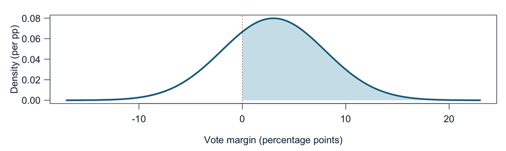

The shaded area is $P(V>0)$, the probability of victory in this model. The parameters are assumptions, not estimates we fit today.

## A normal density and its CDF

For $V\sim\operatorname{Norm}(3,5)$, $F_V(x)=P(V\le x)$.

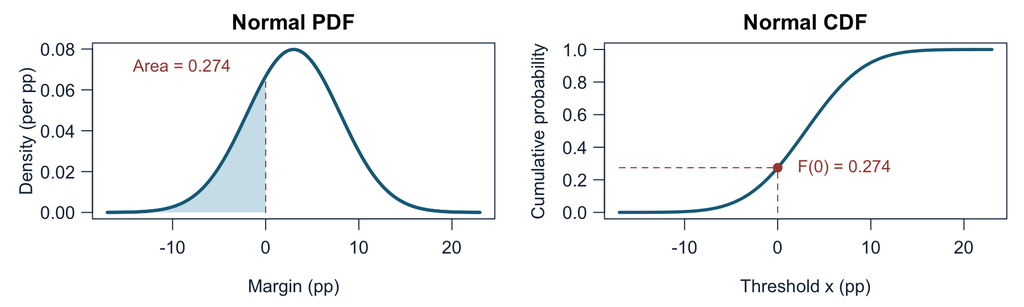

The shaded **area** on the left equals the **height** on the right: $F_V(0)\approx0.274$. The win probability is $1-F_V(0)\approx0.726$.

The CDF rises fastest where the density is highest.

## Win probabilities and close elections

```r
pnorm(0, mean = 3, sd = 5, lower.tail = FALSE)
```

```
[1] 0.7257469
```

```r
pnorm(1, mean = 3, sd = 5) - pnorm(-1, mean = 3, sd = 5)
```

```
[1] 0.1327229
```

The first expression gives $P(V>0)$. The second gives $P(-1\le V\le1)$.

Write the event and its CDF expression before choosing the R command.

**Demo 3:** Compare these areas with `dnorm(0, 3, 5)`.

## The forecast mean and the chance of victory

Hold the SD at 5 and the victory threshold at zero. Vary the assumed mean $\mu$:

$$P(V>0)=\Phi(\mu/5),\qquad \Phi(z)=P(Z\le z),\quad Z\sim\operatorname{Norm}(0,1).$$

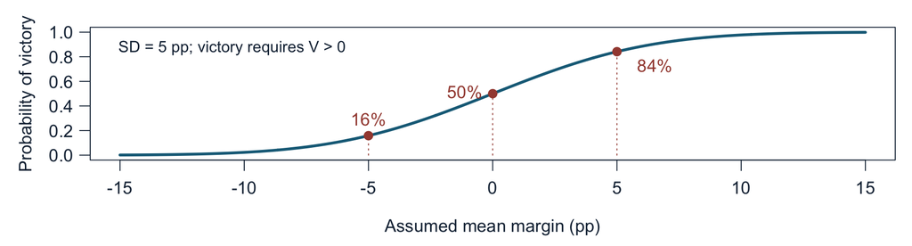

Here the horizontal axis changes the **mean of the distribution**. The previous CDF moved a **threshold within one fixed distribution**.

## Density at a tie

For this model, $f_V(0)\approx0.06664$ per percentage point.

| $\epsilon$ (pp) | Interval width | $P(-\epsilon\le V\le\epsilon)$ |
| --- | --- | --- |
| 0.5 | 1.00 | 0.066574 |
| 0.1 | 0.20 | 0.013328 |
| 0.01 | 0.02 | 0.001333 |

For narrow intervals, probability is approximately **width times density**.

As the width shrinks, the probability tends to zero. Its ratio to the width tends to $f_V(0)$.

## Quantiles run the CDF backward

Start at a cumulative probability, move across to the curve, then down to its margin threshold.

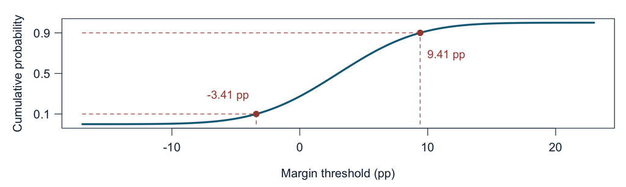

`qnorm(c(.10, .90), mean = 3, sd = 5)` gives $-3.41$ and $9.41$. These enclose the middle **80%** of future margins under this model.

## A central forecast interval

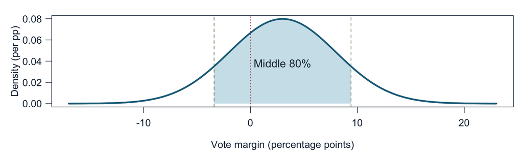

The endpoints are approximately $-3.41$ and $9.41$ percentage points. The total area outside is $0.20$, divided equally between the tails.

This describes the **random final margin**, given the model, rather than a confidence interval for an unknown mean.

## Simulating the forecast

```r
set.seed(93004)
v <- rnorm(50000, mean = 3, sd = 5)
c(win = mean(v > 0), mean = mean(v), variance = var(v))
```

```
      win      mean  variance
 0.725400  3.005628 25.142743
```

**Demo 4:** Compare CDF calculations and model moments with the simulation.

The number of draws controls simulation accuracy. The supplied $\sigma=5$ controls variation across possible election margins.

## A continuous margin and a discrete payoff

A hypothetical contract costs $1.50 and pays $2 for a victory:

$$W=\begin{cases}2,&V>0,\\0,&V\le0,\end{cases}
\qquad Z=W-1.50.$$

Let $p=P(V>0)$. Then

| Net profit $z$ | $-1.50$ | $0.50$ |
| --- | --- | --- |
| $P(Z=z)$ | $1-p$ | $p$ |

The margin $V$ is continuous in the model. The payout and profit are discrete.

## A likely profit and an expected profit

For the contract,

$$E[Z]=2p-1.50,\qquad \operatorname{Var}(Z)=4p(1-p).$$

Here $p\approx0.726$, so the probability of profit exceeds one half, but expected profit is about **minus five cents**.

The loss is three times the size of the gain.

**Demo 6:** Transform each simulated margin into its corresponding payout. Changing a fixed price shifts the mean profit, leaving variance unchanged.

## A discrete election model

Exactly 200 voters choose A or B independently. Each chooses A with probability $p=0.5$.

$$K=\text{votes for A}\sim\operatorname{Binom}(200,0.5).$$

$$E[K]=100,\qquad \operatorname{SD}(K)=\sqrt{50}\approx7.07.$$

$K$ is a count. A tie, $K=100$, has positive probability.

These independence and common-probability assumptions define a toy model.

## A normal approximation to the count

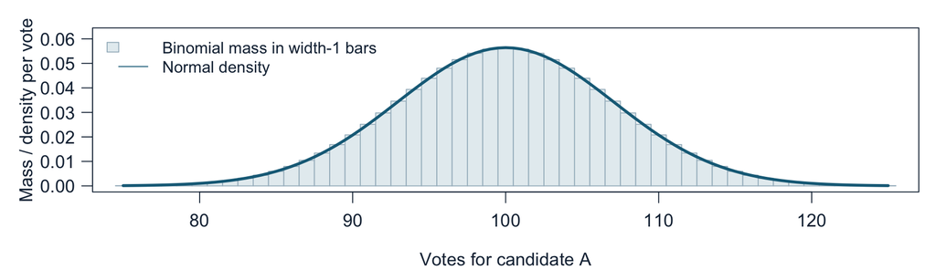

Match the binomial mean and SD with $K^*\sim\operatorname{Norm}(100,\sqrt{50})$.

Each displayed binomial bar has width one vote and area $P(K=k)$.

## An exact tie becomes an interval

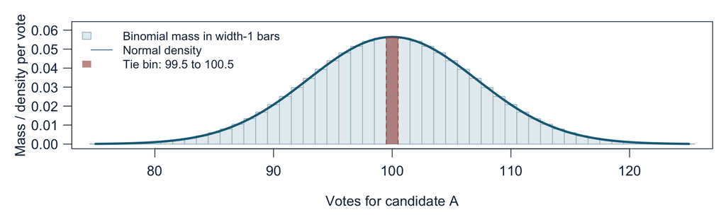

$$P(K=100)\approx P(99.5<K^*<100.5).$$

The half-vote boundaries form a **continuity correction**. They assign the mass at 100 to its surrounding unit-width bin.

## Exact and approximate election probabilities

```r
sd_count <- sqrt(200 * .5 * .5)
dbinom(100, size = 200, prob = .5)
```

```
[1] 0.05634848
```

```r
pnorm(100.5, 100, sd_count) - pnorm(99.5, 100, sd_count)
```

```
[1] 0.05637198
```

Both are about $0.0564$.

A **strict victory** is $K\ge101$, approximated by $K^*>100.5$. It has probability about $0.4718$, not $0.5$.

**Demo 5:** Compare exact probabilities, the approximation, and simulated counts.

## Counts and percentage-point margins

In a two-candidate election with $n$ votes,

$$V=100\left(\frac{K}{n}-\frac{n-K}{n}\right)
=\frac{200K}{n}-100.$$

A one-vote increment changes the margin by $200/n$ percentage points.

The tie bin in margin units is $(-100/n,100/n)$. For $n=200$, that is $(-0.5,0.5)$ percentage points.

Probabilities agree across units when we transform both the interval and the distribution.

## Assumptions behind the approximation

- Independent Bernoulli votes with a common $p$ give a binomial count.
- Independent votes with different $p_i$ give a Poisson-binomial count.
- Dependence between votes can change the count’s variance and shape.

A normal approximation works best when the count has enough variation and neither boundary is too close to its center.

Next week: a fuller account of why sums often have approximately normal distributions.

## A forecast has additional sources of uncertainty

The binomial example assumes a known $p$ and a fixed electorate size.

A forecast may also represent uncertainty about support, turnout, or shared errors.

B2 supplies a hypothetical normal margin model directly. Its parameters do not come from a specified binomial electorate.

The count example explains how a continuous approximation can assign zero probability to a point even when the discrete event has positive probability.

## B2 programming: values and their weights

```r
costs <- c(5, 15, 15, 45)
values <- sort(unique(costs))
counts <- as.numeric(table(factor(costs, levels = values)))
probability <- counts / length(costs)
data.frame(values, probability, cdf = cumsum(probability))
```

```
  values probability  cdf
1      5        0.25 0.25
2     15        0.50 0.75
3     45        0.25 1.00
```

**Demo 7:** Compute moments by probability weights and by all four people.

For this finite population, use `mean((costs - mean(costs))^2)` for variance.

## B2 programming: a loop over decisions

For each offer, calculate its payoff against every possible partner.

```r
for (i in seq_len(nrow(result))) {
  offer <- result$offer[i]
  payoff <- ifelse(costs <= offer, budget - offer, 0)
  result$expected[i] <- mean(payoff)
  result$variance[i] <- mean((payoff - mean(payoff))^2)
}
```

**Demo 9** supplies the complete function and result table. Row 1 corresponds to offer 0, so the row index differs from the offer.

This loop calculates exact finite-population quantities. Random sampling with replacement provides a separate simulation check.

## Questions to carry into B2

1. What is the random experiment, and what stays fixed?
2. Does the calculation require a mass, an area, a quantile, or a moment?
3. Are we averaging transformed outcomes or transforming an average?
4. Could two offers have crossing payoff CDFs?
5. Which differences reflect simulation error rather than model uncertainty?

Keep written derivations and interpretations outside R chunks. Render from a fresh session and commit both the QMD and current HTML.

## Reading and references

Speegle and Clair, [*Probability, Statistics, and Data*, Chapter 4](https://probstatsdata.com/continuousrandomvariables.html).

- Sections 4.1-4.3: densities, CDFs, expectation, and variance.
- Sections 4.4.1-4.4.2: normal computations and the binomial approximation.

The waiting-time, project-partner, and forecast examples are hypothetical course examples. All figures are reproducible from the accompanying R code.

R help: `?Uniform`, `?Normal`, `?Binomial`, and `?ecdf`.

Point-probability intuition adapted from Matt Blackwell’s random-variables lecture, slide 16, used with permission.